**CS4132 Data Analytics**

# Gambling: An Analysis of Gambling as Entertainment by [Kenneth Yeap]

Important Note: Please keep your report concise and relevant (i.e. show only relevant steps and visualizations used to answer your research questions).

# Table of Content (with relevant hyperlinks to sections)

Motivation & Background

Summary of Research Question & Results

Dataset

Methodology

Data Acquisition

Data Cleaning

EDA

Results Findings & Conclusion

Reccomendations & Further Works

References

# Motivation and Background

Give an overview of the project, motivation, background and goals.

Gambling in the modern era tend to have a negative connotation, with direct assotiation to terms like "addiction" and "wasting money". However, at the core of it, gambling is a form of entertainment that deals with chance and luck and in reality is not limited to adults. Gachapon machines in Japan for example is a form of "gambling" targeted at mostly children. The motivation of this project is to shed a light on the gambling industry as a form of entertainment and to understand how much impact it has on the economy; the goal of the project to analyze the gambling industry.

# Summary of Research Questions & Results

Repeat your research questions in a numbered list. After each research question, clearly state the answer/conclusion you determined. Do not give details or justifications yet — just the answer

1. What form of gambling would be the best from the (gambling) industry's and the gambler's point of view?

# Dataset

Numbered list of dataset (with downloadable links) and a brief but clear description of each dataset used. Draw reference to the numbering when describing methodology (data cleaning and analysis).

1. http://www.thetransparencyproject.org/datasets/AnalyticDataset_Gray_LaPlante_PAB_2012.sav

This is the direct download link to the dataset I've used. (http://www.thetransparencyproject.org/download_index.php) This is the link to the entire page and search for "Behavioral Characteristics of Internet Gamblers Who Trigger Corporate Responsible Gambling Interventions" for the extra information and the codebook.

# Methodology

You should demonstrate the data science life cycle here (from data acquisition to cleaning to EDA and analysis etc).

The methodology I used is as follows: search for data -> import data -> clean data -> EDA -> analysize EDA -> remove unneccesary EDA -> retry until acquired results.

To expand from here, I have searched the entire Internet for gambling data. Many datasets I could've acquired are locked behind a pay wall, until I hit The Transparency Project websites which provided a lot of raw datasets. I have downloaded many of them and in my initial testing, thought I needed any of them. However, as I progressed, I realise I don't understand the datasets and it's hard to join two of these datasets and end up abandoning almost all of them.

Importing the data is straightfoward. I faced a huge problem, which was I that I had to import and extra .sav and .sas7bdat files. It took me an entire week to solve this issue since the pyreadstat didn't want to cooperate with me.

The EDA process was the hardest part since I had very little skill in using what I've learnt in practise. I ended up using mostly barcharts and some stripplots since I'm more comfortable with that.

## Data Acquisition

Display the data which will be used in the project. The data should be saved in .xlsx or .csv format to be submitted with the project. If webscraping has been done to obtain your data, save your webscraping code in another jupyter notebook as appendix to be submitted separately from the report. Import and display each dataset in a dataframe. For each dataset, give a brief overview of the data it contains, and explain the meaning of columns that are relevant to the project.

```python
# imports
import pandas as pd
import numpy as np
import seaborn as sns
import matplotlib.pyplot as plt
import pyreadstat
from scipy import stats
```

```python
PAB_data = pd.read_spss("Gray_LaPlante_PAB_2012_AnalyticDataset.sav")
PAB_data
```

|  | UserID | RG_case | Missing_Daily_Transactions | First_Deposit_Date | Registration_date | CountryName | LanguageName | Gender | YearofBirth | age_at_registration | ... | percent_lost_liveaction_sqrt_zeros | sum_stakes_casino_sqrt_zeros | sum_bets_casino_sqrt_zeros | bettingdays_casino_sqrt_zeros | duration_casino_sqrt_zeros | frequency_casino_sqrt_zeros | bets_per_day_casino_sqrt_zeros | euros_per_bet_casino_sqrt_zeros | net_loss_casino_sqrt_zeros | percent_lost_casino_sqrt_zeros |
| --- | --- | --- | --- | --- | --- | --- | --- | --- | --- | --- | --- | --- | --- | --- | --- | --- | --- | --- | --- | --- | --- |
| 0 | 31965.0 | RG case | not missing | 2000-05-08 | 1999-09-17 | Germany.COM | German | male | 1971.0 | 27.0 | ... | 2.851736 | 142.712473 | 40.890097 | 4.242641 | 36.290495 | 0.116908 | 9.637888 | 3.490148 | 191.729627 | 2.654166 |
| 1 | 32639.0 | control | not missing | 2002-11-21 | 1999-10-03 | Austria | German | male | 1969.0 | 29.0 | ... | 3.000000 | 0.000000 | 0.000000 | 0.000000 | 0.000000 | 0.000000 | 0.000000 | 0.000000 | 0.000000 | 0.000000 |
| 2 | 36822.0 | control | not missing | 2000-05-08 | 2000-03-20 | Austria | German | male | 1970.0 | 29.0 | ... | 2.640234 | 0.000000 | 0.000000 | 0.000000 | 0.000000 | 0.000000 | 0.000000 | 0.000000 | 0.000000 | 0.000000 |
| 3 | 36916.0 | RG case | not missing | 2000-06-13 | 2000-03-21 | Austria | German | male | 1969.0 | 31.0 | ... | 3.000000 | 144.536328 | 95.885348 | 2.828427 | 55.461698 | 0.050998 | 33.900590 | 1.507387 | 192.330445 | 2.656035 |
| 4 | 38386.0 | RG case | not missing | 2000-06-09 | 2000-04-21 | Austria | German | male | 1974.0 | 25.0 | ... | 0.000000 | 2.000000 | 2.000000 | 1.000000 | 1.000000 | 1.000000 | 2.000000 | 1.000000 | 189.356806 | 2.828427 |
| ... | ... | ... | ... | ... | ... | ... | ... | ... | ... | ... | ... | ... | ... | ... | ... | ... | ... | ... | ... | ... | ... |
| 4127 | 9821694.0 | control | not missing | 2009-11-21 | NaN | . | . | male | NaN | NaN | ... | 0.000000 | 0.000000 | 0.000000 | 0.000000 | 0.000000 | 0.000000 | 0.000000 | 0.000000 | 0.000000 | 0.000000 |
| 4128 | 9822065.0 | RG case | not missing | 2009-11-21 | 2009-11-21 | Germany.COM | German | female | 1963.0 | 46.0 | ... | 2.855253 | 0.000000 | 0.000000 | 0.000000 | 0.000000 | 0.000000 | 0.000000 | 0.000000 | 0.000000 | 0.000000 |
| 4129 | 9822269.0 | control | not missing | 2009-11-21 | 2009-11-21 | Poland | Polish | female | 1985.0 | 24.0 | ... | 0.000000 | 0.000000 | 0.000000 | 0.000000 | 0.000000 | 0.000000 | 0.000000 | 0.000000 | 0.000000 | 0.000000 |
| 4130 | 9858876.0 | RG case | not missing | 2009-11-27 | 2009-11-27 | Belgium | Dutch | male | 1978.0 | 31.0 | ... | 0.000000 | 93.961428 | 16.643317 | 1.000000 | 1.000000 | 1.000000 | 16.643317 | 5.645595 | 193.989690 | 2.683582 |
| 4131 | 9859152.0 | control | not missing | 2009-11-27 | 2009-11-27 | Germany.COM | German | male | 1982.0 | 27.0 | ... | 3.000000 | 0.000000 | 0.000000 | 0.000000 | 0.000000 | 0.000000 | 0.000000 | 0.000000 | 0.000000 | 0.000000 |

4132 rows × 97 columns

```python
PAB_data.columns
```

```
Index(['UserID', 'RG_case', 'Missing_Daily_Transactions', 'First_Deposit_Date',
       'Registration_date', 'CountryName', 'LanguageName', 'Gender',
       'YearofBirth', 'age_at_registration', 'sum_stakes_fixedodds',
       'sum_bets_fixedodds', 'bettingdays_fixedodds', 'duration_fixedodds',
       'frequency_fixedodds', 'bets_per_day_fixedodds',
       'euros_per_bet_fixedodds', 'net_loss_fixedodds',
       'percent_lost_fixedodds', 'sum_stakes_liveaction',
       'sum_bets_liveaction', 'bettingdays_liveaction', 'duration_liveaction',
       'frequency_liveaction', 'bets_per_day_liveaction',
       'euros_per_bet_liveaction', 'net_loss_liveaction',
       'percent_lost_liveaction', 'sum_stakes_casino', 'sum_bets_casino',
       'bettingdays_casino', 'duration_casino', 'frequency_casino',
       'bets_per_day_casino', 'euros_per_bet_casino', 'net_loss_casino',
       'percent_lost_casino', 'net_loss_fixedodds_nonzero',
       'percent_lost_fixedodds_nonzero', 'net_loss_liveaction_nonzero',
       'percent_lost_liveaction_nonzero', 'net_loss_casino_nonzero',
       'percent_lost_casino_nonzero', 'sum_stakes_fixedodds_sqrt',
       'sum_bets_fixedodds_sqrt', 'bettingdays_fixedodds_sqrt',
       'duration_fixedodds_sqrt', 'frequency_fixedodds_sqrt',
       'bets_per_day_fixedodds_sqrt', 'euros_per_bet_fixedodds_sqrt',
       'net_loss_fixedodds_nonzero_sqrt',
       'percent_lost_fixedodds_nonzero_sqrt', 'sum_stakes_liveaction_sqrt',
       'sum_bets_liveaction_sqrt', 'bettingdays_liveaction_sqrt',
       'duration_liveaction_sqrt', 'frequency_liveaction_sqrt',
       'bets_per_day_liveaction_sqrt', 'euros_per_bet_liveaction_sqrt',
       'net_loss_liveaction_nonzero_sqrt',
       'percent_lost_liveaction_nonzero_sqrt', 'sum_stakes_casino_sqrt',
       'sum_bets_casino_sqrt', 'bettingdays_casino_sqrt',
       'duration_casino_sqrt', 'frequency_casino_sqrt',
       'bets_per_day_casino_sqrt', 'euros_per_bet_casino_sqrt',
       'net_loss_casino_nonzero_sqrt', 'percent_lost_casino_nonzero_sqrt',
       'sum_stakes_fixedodds_sqrt_zeros', 'sum_bets_fixedodds_sqrt_zeros',
       'bettingdays_fixedodds_sqrt_zeros', 'duration_fixedodds_sqrt_zeros',
       'frequency_fixedodds_sqrt_zeros', 'bets_per_day_fixedodds_sqrt_zeros',
       'euros_per_bet_fixedodds_sqrt_zeros', 'net_loss_fixedodds_sqrt_zeros',
       'percent_lost_fixedodds_sqrt_zeros', 'sum_stakes_liveaction_sqrt_zeros',
       'sum_bets_liveaction_sqrt_zeros', 'bettingdays_liveaction_sqrt_zeros',
       'duration_liveaction_sqrt_zeros', 'frequency_liveaction_sqrt_zeros',
       'bets_per_day_liveaction_sqrt_zeros',
       'euros_per_bet_liveaction_sqrt_zeros', 'net_loss_liveaction_sqrt_zeros',
       'percent_lost_liveaction_sqrt_zeros', 'sum_stakes_casino_sqrt_zeros',
       'sum_bets_casino_sqrt_zeros', 'bettingdays_casino_sqrt_zeros',
       'duration_casino_sqrt_zeros', 'frequency_casino_sqrt_zeros',
       'bets_per_day_casino_sqrt_zeros', 'euros_per_bet_casino_sqrt_zeros',
       'net_loss_casino_sqrt_zeros', 'percent_lost_casino_sqrt_zeros'],
      dtype='object')
```

## Data Cleaning

For data cleaning, be clear in which dataset (or variables) are used, what has been done for missing data, how was merging performed, explanation of data transformation (if any). If data is calculated or summarized from the raw dataset, explain the rationale and steps clearly.

```python
PAB_data.First_Deposite_Date = pd.to_datetime(PAB_data.First_Deposit_Date, format="%Y-%m-%d", infer_datetime_format=True)
PAB_data.Registration_date = pd.to_datetime(PAB_data.Registration_date, format="%Y-%m-%d", infer_datetime_format=True)
PAB_data[["UserID","YearofBirth","age_at_registration"]] = PAB_data[["UserID","YearofBirth","age_at_registration"]].astype("int32",errors = 'ignore')
PAB_data
```

|  | UserID | RG_case | Missing_Daily_Transactions | First_Deposit_Date | Registration_date | CountryName | LanguageName | Gender | YearofBirth | age_at_registration | ... | percent_lost_liveaction_sqrt_zeros | sum_stakes_casino_sqrt_zeros | sum_bets_casino_sqrt_zeros | bettingdays_casino_sqrt_zeros | duration_casino_sqrt_zeros | frequency_casino_sqrt_zeros | bets_per_day_casino_sqrt_zeros | euros_per_bet_casino_sqrt_zeros | net_loss_casino_sqrt_zeros | percent_lost_casino_sqrt_zeros |
| --- | --- | --- | --- | --- | --- | --- | --- | --- | --- | --- | --- | --- | --- | --- | --- | --- | --- | --- | --- | --- | --- |
| 0 | 31965.0 | RG case | not missing | 2000-05-08 | 1999-09-17 | Germany.COM | German | male | 1971.0 | 27.0 | ... | 2.851736 | 142.712473 | 40.890097 | 4.242641 | 36.290495 | 0.116908 | 9.637888 | 3.490148 | 191.729627 | 2.654166 |
| 1 | 32639.0 | control | not missing | 2002-11-21 | 1999-10-03 | Austria | German | male | 1969.0 | 29.0 | ... | 3.000000 | 0.000000 | 0.000000 | 0.000000 | 0.000000 | 0.000000 | 0.000000 | 0.000000 | 0.000000 | 0.000000 |
| 2 | 36822.0 | control | not missing | 2000-05-08 | 2000-03-20 | Austria | German | male | 1970.0 | 29.0 | ... | 2.640234 | 0.000000 | 0.000000 | 0.000000 | 0.000000 | 0.000000 | 0.000000 | 0.000000 | 0.000000 | 0.000000 |
| 3 | 36916.0 | RG case | not missing | 2000-06-13 | 2000-03-21 | Austria | German | male | 1969.0 | 31.0 | ... | 3.000000 | 144.536328 | 95.885348 | 2.828427 | 55.461698 | 0.050998 | 33.900590 | 1.507387 | 192.330445 | 2.656035 |
| 4 | 38386.0 | RG case | not missing | 2000-06-09 | 2000-04-21 | Austria | German | male | 1974.0 | 25.0 | ... | 0.000000 | 2.000000 | 2.000000 | 1.000000 | 1.000000 | 1.000000 | 2.000000 | 1.000000 | 189.356806 | 2.828427 |
| ... | ... | ... | ... | ... | ... | ... | ... | ... | ... | ... | ... | ... | ... | ... | ... | ... | ... | ... | ... | ... | ... |
| 4127 | 9821694.0 | control | not missing | 2009-11-21 | NaT | . | . | male | NaN | NaN | ... | 0.000000 | 0.000000 | 0.000000 | 0.000000 | 0.000000 | 0.000000 | 0.000000 | 0.000000 | 0.000000 | 0.000000 |
| 4128 | 9822065.0 | RG case | not missing | 2009-11-21 | 2009-11-21 | Germany.COM | German | female | 1963.0 | 46.0 | ... | 2.855253 | 0.000000 | 0.000000 | 0.000000 | 0.000000 | 0.000000 | 0.000000 | 0.000000 | 0.000000 | 0.000000 |
| 4129 | 9822269.0 | control | not missing | 2009-11-21 | 2009-11-21 | Poland | Polish | female | 1985.0 | 24.0 | ... | 0.000000 | 0.000000 | 0.000000 | 0.000000 | 0.000000 | 0.000000 | 0.000000 | 0.000000 | 0.000000 | 0.000000 |
| 4130 | 9858876.0 | RG case | not missing | 2009-11-27 | 2009-11-27 | Belgium | Dutch | male | 1978.0 | 31.0 | ... | 0.000000 | 93.961428 | 16.643317 | 1.000000 | 1.000000 | 1.000000 | 16.643317 | 5.645595 | 193.989690 | 2.683582 |
| 4131 | 9859152.0 | control | not missing | 2009-11-27 | 2009-11-27 | Germany.COM | German | male | 1982.0 | 27.0 | ... | 3.000000 | 0.000000 | 0.000000 | 0.000000 | 0.000000 | 0.000000 | 0.000000 | 0.000000 | 0.000000 | 0.000000 |

4132 rows × 97 columns

## EDA

For each research questions shortlisted, outline your methodology in answering them. Discuss interesting observations or results discovered. Please note to only show EDA that's relevant to answering the question at hand. If you have done any data modeling, include in this section.

Question 1:

```python
## First, I removed some of the control data that is present which have NaN data. This would've been part of data cleaning,
## but because the dataset is shared, I chose to make a new DataFrame from the original one.

PAB_data_case = pd.concat([PAB_data[PAB_data.RG_case == "RG case"],PAB_data[PAB_data.RG_case == "control"].dropna()])
PAB_data_case
```

|  | UserID | RG_case | Missing_Daily_Transactions | First_Deposit_Date | Registration_date | CountryName | LanguageName | Gender | YearofBirth | age_at_registration | ... | percent_lost_liveaction_sqrt_zeros | sum_stakes_casino_sqrt_zeros | sum_bets_casino_sqrt_zeros | bettingdays_casino_sqrt_zeros | duration_casino_sqrt_zeros | frequency_casino_sqrt_zeros | bets_per_day_casino_sqrt_zeros | euros_per_bet_casino_sqrt_zeros | net_loss_casino_sqrt_zeros | percent_lost_casino_sqrt_zeros |
| --- | --- | --- | --- | --- | --- | --- | --- | --- | --- | --- | --- | --- | --- | --- | --- | --- | --- | --- | --- | --- | --- |
| 0 | 31965.0 | RG case | not missing | 2000-05-08 | 1999-09-17 | Germany.COM | German | male | 1971.0 | 27.0 | ... | 2.851736 | 142.712473 | 40.890097 | 4.242641 | 36.290495 | 0.116908 | 9.637888 | 3.490148 | 191.729627 | 2.654166 |
| 3 | 36916.0 | RG case | not missing | 2000-06-13 | 2000-03-21 | Austria | German | male | 1969.0 | 31.0 | ... | 3.000000 | 144.536328 | 95.885348 | 2.828427 | 55.461698 | 0.050998 | 33.900590 | 1.507387 | 192.330445 | 2.656035 |
| 4 | 38386.0 | RG case | not missing | 2000-06-09 | 2000-04-21 | Austria | German | male | 1974.0 | 25.0 | ... | 0.000000 | 2.000000 | 2.000000 | 1.000000 | 1.000000 | 1.000000 | 2.000000 | 1.000000 | 189.356806 | 2.828427 |
| 8 | 91707.0 | RG case | not missing | 2000-06-25 | 2000-06-24 | Austria | German | male | 1966.0 | 34.0 | ... | 2.817467 | 2463.472092 | 428.330480 | 28.896367 | 45.836667 | 0.630420 | 14.822987 | 5.751335 | 429.788599 | 2.650383 |
| 13 | 107124.0 | RG case | not missing | 2000-07-09 | 2000-07-09 | Austria | German | male | 1975.0 | 24.0 | ... | 2.832259 | 291.085245 | 124.791827 | 11.090537 | 49.081565 | 0.225961 | 11.252100 | 2.332567 | 197.637092 | 2.652898 |
| ... | ... | ... | ... | ... | ... | ... | ... | ... | ... | ... | ... | ... | ... | ... | ... | ... | ... | ... | ... | ... | ... |
| 4048 | 9442366.0 | control | not missing | 2009-09-22 | 2009-09-22 | Germany.COM | German | male | 1973.0 | 35.0 | ... | 2.743634 | 40.168396 | 17.832555 | 1.414214 | 1.414214 | 1.000000 | 12.609520 | 2.252532 | 189.611445 | 2.657496 |
| 4063 | 9470262.0 | control | not missing | 2009-09-26 | 2009-09-26 | Portugal | Portuguese | male | 1978.0 | 30.0 | ... | 2.856033 | 57.276959 | 21.470911 | 3.316625 | 19.078784 | 0.173838 | 6.473723 | 2.667654 | 189.199234 | 2.642544 |
| 4110 | 9679378.0 | control | not missing | 2009-10-28 | 2009-10-28 | Greece.BAW | Greek | male | 1982.0 | 27.0 | ... | 2.851772 | 36.606010 | 12.922848 | 4.472136 | 11.445523 | 0.390732 | 2.889637 | 2.832658 | 189.570567 | 2.657712 |
| 4111 | 9679637.0 | control | not missing | 2009-10-28 | 2009-10-28 | Germany.COM | German | male | 1991.0 | 18.0 | ... | 2.856975 | 9.313431 | 9.643651 | 1.414214 | 7.745967 | 0.182574 | 6.819091 | 0.965758 | 189.401954 | 2.691330 |
| 4119 | 9744092.0 | control | not missing | 2009-11-08 | 2009-11-07 | Germany.COM | German | male | 1987.0 | 22.0 | ... | 2.840111 | 4.774935 | 4.795832 | 1.414214 | 12.767145 | 0.110770 | 3.391165 | 0.995643 | 189.372913 | 2.728183 |

2391 rows × 97 columns

```
duration_fixedodds     766.5
duration_liveaction    726.0
duration_casino        250.0
dtype: float64
```

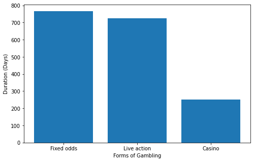

```python
plt.figure(figsize=(8,5))

PAB_data_case_duration_median = PAB_data_case[["duration_fixedodds","duration_liveaction","duration_casino"]].median()
plt.bar(["Fixed odds","Live action","Casino"],PAB_data_case_duration_median)
plt.xlabel("Forms of Gambling")
plt.ylabel("Duration (Days)")

PAB_data_case_duration_median
```

```python
#I wanted to see how much a gambler spent per day in each category and see if there's any relation to the duration they gamble.

spent_fixedodds = PAB_data_case["bets_per_day_fixedodds"]*PAB_data_case["euros_per_bet_fixedodds"]
spent_liveaction = PAB_data_case["bets_per_day_liveaction"]*PAB_data_case["euros_per_bet_liveaction"]
spent_casino = PAB_data_case["bets_per_day_casino"]*PAB_data_case["euros_per_bet_casino"]

PAB_data_case_spent = pd.DataFrame({"spent_fixedodds":spent_fixedodds,"spent_liveaction":spent_liveaction,"spent_casino":spent_casino})
PAB_data_case_spent
```

|  | spent_fixedodds | spent_liveaction | spent_casino |
| --- | --- | --- | --- |
| 0 | 19.995474 | 99.123466 | 1131.491667 |
| 3 | 51.446866 | 39.500000 | 2611.343750 |
| 4 | 6.977567 | NaN | 4.000000 |
| 8 | 66.281598 | 50.500000 | 7267.897904 |
| 13 | 214.185311 | 187.864752 | 688.866829 |
| ... | ... | ... | ... |
| 4048 | 30.000000 | 24.340000 | 806.750000 |
| 4063 | 5.581111 | 224.610377 | 298.240909 |
| 4110 | 18.917500 | 36.858333 | 67.000000 |
| 4111 | 36.122667 | 27.078333 | 43.370000 |
| 4119 | 7.907000 | 22.909091 | 11.400000 |

2391 rows × 3 columns

```
spent_fixedodds      21.873200
spent_liveaction     58.430355
spent_casino        198.194211
dtype: float64
```

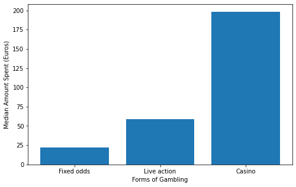

```python
plt.figure(figsize=(8,5))

plt.bar(["Fixed odds","Live action","Casino"],PAB_data_case_spent.median())
plt.xlabel("Forms of Gambling")
plt.ylabel("Median Amount Spent (Euros)")

PAB_data_case_spent.median()
```

```python
#And with this, I wanted to look at how much a gambler losses in each form of gambling.

PAB_data_case_loss = PAB_data_case[["net_loss_fixedodds","net_loss_liveaction","net_loss_casino"]]
PAB_data_case_loss
```

|  | net_loss_fixedodds | net_loss_liveaction | net_loss_casino |
| --- | --- | --- | --- |
| 0 | 1459.0826 | 12494.0200 | 908.25 |
| 3 | 551.2031 | 79.0000 | 1139.00 |
| 4 | 73.2527 | NaN | 4.00 |
| 8 | -42.8122 | -6.2500 | 148866.24 |
| 13 | 7857.0878 | 1267.2378 | 3208.42 |
| ... | ... | ... | ... |
| 4048 | 60.0000 | -23.0000 | 100.50 |
| 4063 | 50.2300 | 1868.0700 | -55.65 |
| 4110 | 164.3500 | 58.6500 | 85.00 |
| 4111 | 318.0400 | 79.1100 | 21.10 |
| 4119 | 35.0300 | 16.6900 | 10.10 |

2391 rows × 3 columns

```
net_loss_fixedodds     154.28225
net_loss_liveaction    197.41500
net_loss_casino         89.20000
dtype: float64
```

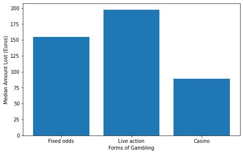

```python
plt.figure(figsize=(8,5))

plt.bar(["Fixed odds","Live action","Casino"],PAB_data_case_loss.median())
plt.xlabel("Forms of Gambling")
plt.ylabel("Median Amount Lost (Euros)")

PAB_data_case_loss.median()
```

```python
#I also took a look the percent lost in each form of gambling to get understand the odds of losing in each form of gambling.

PAB_data_case_lost = PAB_data_case[["percent_lost_fixedodds","percent_lost_liveaction","percent_lost_casino"]]
PAB_data_case_lost
```

|  | percent_lost_fixedodds | percent_lost_liveaction | percent_lost_casino |
| --- | --- | --- | --- |
| 0 | 0.186626 | 0.132400 | 0.044595 |
| 3 | 0.126047 | 1.000000 | 0.054522 |
| 4 | 0.291620 | NaN | 1.000000 |
| 8 | -0.015021 | -0.061881 | 0.024530 |
| 13 | 0.166744 | 0.021690 | 0.037866 |
| ... | ... | ... | ... |
| 4048 | 1.000000 | -0.472473 | 0.062287 |
| 4063 | 1.000000 | 0.156923 | -0.016963 |
| 4110 | 0.434386 | 0.132602 | 0.063433 |
| 4111 | 0.195654 | 0.162307 | 0.243256 |
| 4119 | 0.443025 | 0.066230 | 0.442982 |

2391 rows × 3 columns

```
percent_lost_fixedodds     0.214543
percent_lost_liveaction    0.092172
percent_lost_casino        0.065257
dtype: float64
```

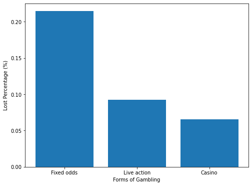

```python
plt.figure(figsize=(8,6))

plt.bar(["Fixed odds","Live action","Casino"],PAB_data_case_lost.median())
plt.xlabel("Forms of Gambling")
plt.ylabel("Lost Percentage (%)")

PAB_data_case_lost.median()
```

```python
# For this one, I wanted to see how much a gambling insitute earns and see if there's an effect.

total_earned_fixedodds = PAB_data_case_spent.spent_fixedodds + PAB_data_case_loss.net_loss_fixedodds
total_earned_liveaction = PAB_data_case_spent.spent_liveaction + PAB_data_case_loss.net_loss_liveaction
total_earned_casino = PAB_data_case_spent.spent_casino + PAB_data_case_loss.net_loss_casino

PAB_data_case_total_earned = pd.DataFrame({"total_earned_fixedodds":total_earned_fixedodds,"total_earned_liveaction":total_earned_liveaction,"total_earned_casino":total_earned_casino})
PAB_data_case_total_earned
```

|  | total_earned_fixedodds | total_earned_liveaction | total_earned_casino |
| --- | --- | --- | --- |
| 0 | 1479.078074 | 12593.143466 | 2039.741667 |
| 3 | 602.649966 | 118.500000 | 3750.343750 |
| 4 | 80.230267 | NaN | 8.000000 |
| 8 | 23.469398 | 44.250000 | 156134.137904 |
| 13 | 8071.273111 | 1455.102552 | 3897.286829 |
| ... | ... | ... | ... |
| 4048 | 90.000000 | 1.340000 | 907.250000 |
| 4063 | 55.811111 | 2092.680377 | 242.590909 |
| 4110 | 183.267500 | 95.508333 | 152.000000 |
| 4111 | 354.162667 | 106.188333 | 64.470000 |
| 4119 | 42.937000 | 39.599091 | 21.500000 |

2391 rows × 3 columns

```
total_earned_fixedodds     183.246763
total_earned_liveaction    289.773866
total_earned_casino        356.195882
dtype: float64
```

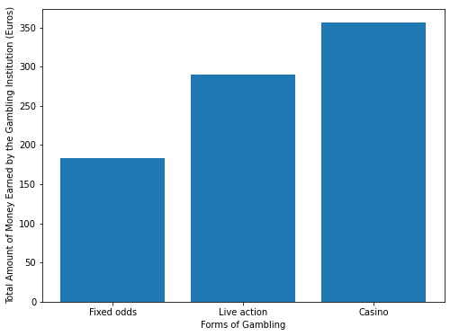

```python
plt.figure(figsize=(8,6))

plt.bar(["Fixed odds","Live action","Casino"],PAB_data_case_total_earned.median())
plt.xlabel("Forms of Gambling")
plt.ylabel("Total Amount of Money Earned by the Gambling Institution (Euros)")

PAB_data_case_total_earned.median()
```

Question 2:

```python
index = PAB_data[["duration_fixedodds","duration_liveaction","duration_casino"]].dropna(how="all").index.to_list()
PAB_data_duration = PAB_data.loc[index][["CountryName","Gender","duration_fixedodds","duration_liveaction","duration_casino"]]
PAB_data_duration.insert(5, "total_duration", PAB_data[["duration_fixedodds","duration_liveaction","duration_casino"]].dropna(how="all").sum(axis="columns"),True)
PAB_data_duration = PAB_data_duration[PAB_data_duration.CountryName != "."].sort_values(by="CountryName").reset_index()
PAB_data_duration
```

|  | index | CountryName | Gender | duration_fixedodds | duration_liveaction | duration_casino | total_duration |
| --- | --- | --- | --- | --- | --- | --- | --- |
| 0 | 819 | Andorra | male | 1770.0 | 1938.0 | NaN | 3708.0 |
| 1 | 4073 | Argentina.AR | female | 367.0 | 396.0 | NaN | 763.0 |
| 2 | 774 | Australia | female | 213.0 | NaN | NaN | 213.0 |
| 3 | 4022 | Australia | male | NaN | 12.0 | 1.0 | 13.0 |
| 4 | 2380 | Australia | male | 248.0 | NaN | NaN | 248.0 |
| ... | ... | ... | ... | ... | ... | ... | ... |
| 3955 | 2823 | United Kingdom | male | 484.0 | 718.0 | NaN | 1202.0 |
| 3956 | 902 | United Kingdom | male | 1254.0 | 691.0 | 1252.0 | 3197.0 |
| 3957 | 3468 | United Kingdom | male | 1.0 | NaN | NaN | 1.0 |
| 3958 | 3802 | United Kingdom | male | 1.0 | NaN | 3.0 | 4.0 |
| 3959 | 127 | United Kingdom | male | 65.0 | 1.0 | 1.0 | 67.0 |

3960 rows × 7 columns

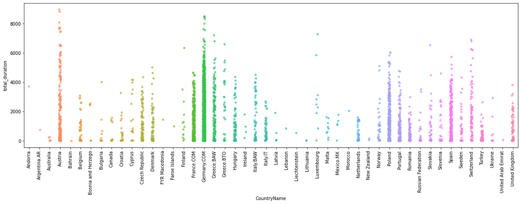

```python
plt.figure(figsize=(20,6))
sns.stripplot(y=PAB_data_duration["total_duration"], x=PAB_data_duration["CountryName"], data=PAB_data_duration, alpha=0.7)
plt.xticks(rotation=90)
plt.show()
```

```python
PAB_data_duration_median = PAB_data_duration.groupby("CountryName").median().sort_values(by="total_duration", ascending=False).reset_index()
PAB_data_duration_median.sort_values(by="total_duration",ascending=False)
```

|  | CountryName | index | duration_fixedodds | duration_liveaction | duration_casino | total_duration |
| --- | --- | --- | --- | --- | --- | --- |
| 0 | Andorra | 819.0 | 1770.0 | 1938.0 | NaN | 3708.0 |
| 1 | Luxembourg | 1594.0 | 1115.5 | 971.5 | 835.0 | 2480.0 |
| 2 | Bosnia and Herzego | 2419.0 | 883.0 | 545.0 | 344.5 | 2434.0 |
| 3 | Greece.BTO | 1389.0 | 1029.5 | 1051.0 | 875.5 | 2350.0 |
| 4 | Morocco | 1125.0 | 1023.0 | 1022.0 | NaN | 2045.0 |
| 5 | Switzerland | 1835.0 | 760.0 | 648.0 | 557.0 | 1509.0 |
| 6 | Greece.BAW | 2677.5 | 685.0 | 644.0 | 368.0 | 1467.0 |
| 7 | FYR Macedonia | 1756.0 | 714.0 | 736.0 | NaN | 1450.0 |
| 8 | Italy.BAW | 1164.0 | 600.5 | 512.0 | 997.0 | 1244.5 |
| 9 | Germany.COM | 1615.0 | 750.5 | 673.0 | 181.0 | 1239.0 |
| 10 | Austria | 1063.0 | 644.0 | 508.5 | 523.0 | 1159.0 |
| 11 | Mexico.MX | 1718.0 | 889.0 | 95.0 | NaN | 1125.0 |
| 12 | Faroe Islands | 358.0 | 483.0 | 4.0 | 502.0 | 989.0 |
| 13 | Poland | 1972.0 | 551.0 | 504.0 | 291.0 | 968.0 |
| 14 | Finland | 3042.0 | 504.0 | 470.0 | 13.0 | 943.0 |
| 15 | Czech Republic | 2251.0 | 476.0 | 506.0 | 54.0 | 910.0 |
| 16 | Norway | 1600.5 | 523.0 | 214.5 | 255.0 | 898.0 |
| 17 | Cyprus | 2659.0 | 617.0 | 662.0 | 276.0 | 846.0 |
| 18 | Lebanon | 2143.0 | 622.0 | 8.0 | 214.0 | 844.0 |
| 19 | Malta | 3081.0 | 383.0 | 151.0 | 82.0 | 821.0 |
| 20 | Ireland | 3225.0 | 313.5 | 222.5 | 307.0 | 783.5 |
| 21 | Argentina.AR | 4073.0 | 367.0 | 396.0 | NaN | 763.0 |
| 22 | Belgium | 3229.5 | 377.0 | 504.5 | 68.0 | 698.0 |
| 23 | Hungary | 2584.5 | 376.0 | 367.0 | 343.0 | 697.5 |
| 24 | France.COM | 2347.0 | 372.0 | 393.5 | 184.0 | 660.0 |
| 25 | Italy.IT | 2469.5 | 509.5 | 328.5 | NaN | 641.0 |
| 26 | Slovakia | 2360.5 | 449.0 | 579.0 | 125.0 | 632.0 |
| 27 | Sweden | 3160.0 | 306.0 | 206.0 | 119.0 | 628.5 |
| 28 | Denmark | 1723.0 | 368.0 | 254.0 | 117.0 | 623.0 |
| 29 | Spain | 2485.0 | 377.5 | 489.0 | 73.0 | 592.0 |
| 30 | United Kingdom | 3127.0 | 278.0 | 275.5 | 111.5 | 555.0 |
| 31 | Liechtenstein | 417.0 | 546.0 | NaN | 2.0 | 548.0 |
| 32 | Netherlands | 3174.5 | 271.0 | 142.0 | 75.0 | 439.0 |
| 33 | Croatia | 2700.0 | 112.5 | 236.0 | 94.0 | 374.5 |
| 34 | Romania | 3290.5 | 184.0 | 154.0 | 51.0 | 320.0 |
| 35 | Slovenia | 2612.0 | 91.0 | 218.0 | 22.5 | 289.0 |
| 36 | Portugal | 2283.0 | 119.0 | 84.0 | 223.0 | 250.0 |
| 37 | Ukraine | 2636.0 | 184.0 | 183.0 | 283.0 | 198.5 |
| 38 | Turkey | 735.0 | 63.5 | 19.0 | 137.5 | 101.0 |
| 39 | New Zealand | 2180.0 | 99.0 | NaN | NaN | 99.0 |
| 40 | Bulgaria | 3644.0 | 90.0 | 157.0 | 9.5 | 98.0 |
| 41 | Russian Federation | 3601.0 | 168.0 | 65.0 | 1.0 | 79.0 |
| 42 | Canada | 3282.0 | 50.5 | 398.0 | 59.0 | 67.0 |
| 43 | United Arab Emirat | 2272.0 | 55.0 | NaN | NaN | 55.0 |
| 44 | Latvia | 3648.0 | 52.0 | 218.0 | 640.0 | 52.0 |
| 45 | Australia | 2846.0 | 119.0 | 12.0 | 1.0 | 25.0 |
| 46 | Lithuania | 3919.5 | 23.0 | 2.0 | 1.0 | 13.0 |
| 47 | Bahrain | 1665.0 | NaN | 1.0 | NaN | 1.0 |

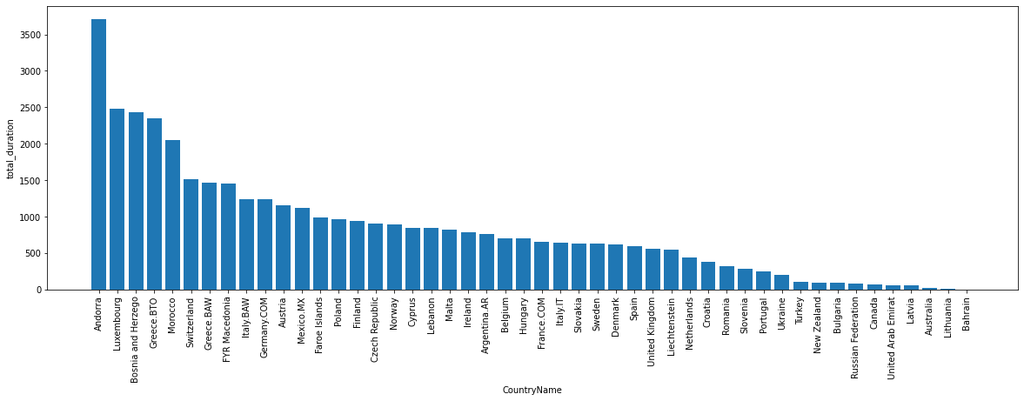

```python
plt.figure(figsize=(20,6))
plt.bar(PAB_data_duration_median.sort_values(by="total_duration", ascending=False).CountryName,PAB_data_duration_median.sort_values(by="total_duration", ascending=False).total_duration)
plt.xticks(rotation=90)
plt.xlabel("CountryName")
plt.ylabel("total_duration")
plt.show()
```

```python
PAB_data_duration_median_10 = PAB_data_duration_median.sort_values(by="total_duration", ascending=False)[:10]
PAB_data_duration_median_10
```

|  | CountryName | index | duration_fixedodds | duration_liveaction | duration_casino | total_duration |
| --- | --- | --- | --- | --- | --- | --- |
| 0 | Andorra | 819.0 | 1770.0 | 1938.0 | NaN | 3708.0 |
| 1 | Luxembourg | 1594.0 | 1115.5 | 971.5 | 835.0 | 2480.0 |
| 2 | Bosnia and Herzego | 2419.0 | 883.0 | 545.0 | 344.5 | 2434.0 |
| 3 | Greece.BTO | 1389.0 | 1029.5 | 1051.0 | 875.5 | 2350.0 |
| 4 | Morocco | 1125.0 | 1023.0 | 1022.0 | NaN | 2045.0 |
| 5 | Switzerland | 1835.0 | 760.0 | 648.0 | 557.0 | 1509.0 |
| 6 | Greece.BAW | 2677.5 | 685.0 | 644.0 | 368.0 | 1467.0 |
| 7 | FYR Macedonia | 1756.0 | 714.0 | 736.0 | NaN | 1450.0 |
| 8 | Italy.BAW | 1164.0 | 600.5 | 512.0 | 997.0 | 1244.5 |
| 9 | Germany.COM | 1615.0 | 750.5 | 673.0 | 181.0 | 1239.0 |

```python
PAB_data_10_duration_median = PAB_data[PAB_data.CountryName.isin(PAB_data_duration_median_10.CountryName)]
PAB_data_10_duration_median
```

|  | UserID | RG_case | Missing_Daily_Transactions | First_Deposit_Date | Registration_date | CountryName | LanguageName | Gender | YearofBirth | age_at_registration | ... | percent_lost_liveaction_sqrt_zeros | sum_stakes_casino_sqrt_zeros | sum_bets_casino_sqrt_zeros | bettingdays_casino_sqrt_zeros | duration_casino_sqrt_zeros | frequency_casino_sqrt_zeros | bets_per_day_casino_sqrt_zeros | euros_per_bet_casino_sqrt_zeros | net_loss_casino_sqrt_zeros | percent_lost_casino_sqrt_zeros |
| --- | --- | --- | --- | --- | --- | --- | --- | --- | --- | --- | --- | --- | --- | --- | --- | --- | --- | --- | --- | --- | --- |
| 0 | 31965.0 | RG case | not missing | 2000-05-08 | 1999-09-17 | Germany.COM | German | male | 1971.0 | 27.0 | ... | 2.851736 | 142.712473 | 40.890097 | 4.242641 | 36.290495 | 0.116908 | 9.637888 | 3.490148 | 191.729627 | 2.654166 |
| 23 | 165200.0 | control | not missing | 2000-11-27 | 2000-11-27 | Germany.COM | German | male | 1977.0 | 23.0 | ... | 2.826269 | 26.391286 | 10.770330 | 3.162278 | 30.182777 | 0.104771 | 3.405877 | 2.450369 | 189.468335 | 2.658271 |
| 25 | 166143.0 | control | not missing | 2001-12-21 | 2000-11-28 | Germany.COM | German | male | 1979.0 | 21.0 | ... | 3.000000 | 0.000000 | 0.000000 | 0.000000 | 0.000000 | 0.000000 | 0.000000 | 0.000000 | 0.000000 | 0.000000 |
| 26 | 167997.0 | control | not missing | 2001-01-25 | 2000-11-30 | Germany.COM | German | male | 1964.0 | 36.0 | ... | 0.000000 | 6.403124 | 2.000000 | 1.414214 | 2.645751 | 0.534522 | 1.414214 | 3.201562 | 189.385850 | 2.714011 |
| 29 | 191415.0 | RG case | not missing | 2001-01-25 | 2001-01-19 | Germany.COM | German | male | 1969.0 | 31.0 | ... | 2.865153 | 25.651511 | 16.881943 | 3.000000 | 33.645208 | 0.089166 | 5.627314 | 1.519464 | 189.504617 | 2.662928 |
| ... | ... | ... | ... | ... | ... | ... | ... | ... | ... | ... | ... | ... | ... | ... | ... | ... | ... | ... | ... | ... | ... |
| 4119 | 9744092.0 | control | not missing | 2009-11-08 | 2009-11-07 | Germany.COM | German | male | 1987.0 | 22.0 | ... | 2.840111 | 4.774935 | 4.795832 | 1.414214 | 12.767145 | 0.110770 | 3.391165 | 0.995643 | 189.372913 | 2.728183 |
| 4121 | 9758033.0 | RG case | not missing | 2009-11-21 | 2009-11-09 | Germany.COM | German | male | 1971.0 | 38.0 | ... | 2.804970 | 0.000000 | 0.000000 | 0.000000 | 0.000000 | 0.000000 | 0.000000 | 0.000000 | 0.000000 | 0.000000 |
| 4122 | 9786180.0 | control | not missing | 2009-11-14 | 2009-11-14 | Germany.COM | German | female | 1985.0 | 24.0 | ... | 3.000000 | 0.000000 | 0.000000 | 0.000000 | 0.000000 | 0.000000 | 0.000000 | 0.000000 | 0.000000 | 0.000000 |
| 4128 | 9822065.0 | RG case | not missing | 2009-11-21 | 2009-11-21 | Germany.COM | German | female | 1963.0 | 46.0 | ... | 2.855253 | 0.000000 | 0.000000 | 0.000000 | 0.000000 | 0.000000 | 0.000000 | 0.000000 | 0.000000 | 0.000000 |
| 4131 | 9859152.0 | control | not missing | 2009-11-27 | 2009-11-27 | Germany.COM | German | male | 1982.0 | 27.0 | ... | 3.000000 | 0.000000 | 0.000000 | 0.000000 | 0.000000 | 0.000000 | 0.000000 | 0.000000 | 0.000000 | 0.000000 |

1905 rows × 97 columns

```python
PAB_data_10_duration_median_loss = PAB_data_10_duration_median[["CountryName","Gender","net_loss_fixedodds","net_loss_liveaction","net_loss_casino"]]
PAB_data_10_duration_median_loss["total_net_loss"] = PAB_data_10_duration_median_loss[["net_loss_fixedodds","net_loss_liveaction","net_loss_casino"]].sum(axis="columns")
PAB_data_10_duration_median_loss.sort_values(by = "total_net_loss")
```

|  | CountryName | Gender | net_loss_fixedodds | net_loss_liveaction | net_loss_casino | total_net_loss |
| --- | --- | --- | --- | --- | --- | --- |
| 2625 | Greece.BAW | male | -33216.7689 | 4776.8100 | 7682.85 | -20757.1089 |
| 1098 | Germany.COM | male | 92.0899 | -17351.6999 | 1917.00 | -15342.6100 |
| 1699 | Germany.COM | male | -1259.5400 | 114.4341 | -7421.22 | -8566.3259 |
| 2210 | Germany.COM | male | 309.0000 | 300.0000 | -8462.50 | -7853.5000 |
| 2428 | Germany.COM | male | -607.5700 | -3316.6006 | NaN | -3924.1706 |
| ... | ... | ... | ... | ... | ... | ... |
| 277 | Greece.BTO | male | 5716.9466 | 14824.3934 | 76351.16 | 96892.5000 |
| 1100 | Germany.COM | male | 25369.5206 | 76333.3794 | NaN | 101702.9000 |
| 400 | Greece.BAW | male | 28075.8669 | 87205.9131 | -110.00 | 115171.7800 |
| 1446 | Germany.COM | male | 3951.2438 | 115932.6410 | NaN | 119883.8848 |
| 93 | Germany.COM | female | 425.9115 | 663.1079 | 151144.64 | 152233.6594 |

1905 rows × 6 columns

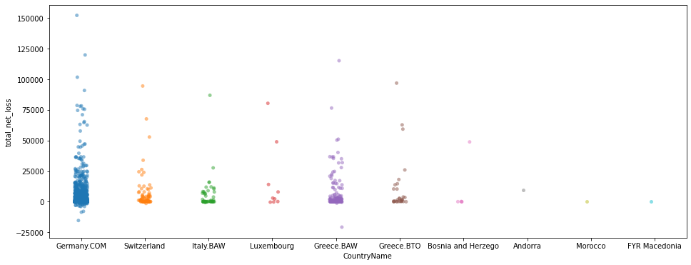

```python
plt.figure(figsize = (16,6))
sns.stripplot(y=PAB_data_10_duration_median_loss.total_net_loss, x=PAB_data_10_duration_median_loss.CountryName, alpha=0.5)
```

```python
PAB_data_10_duration_median_bets = PAB_data_10_duration_median[["CountryName","Gender","sum_bets_fixedodds","euros_per_bet_fixedodds","sum_bets_liveaction","euros_per_bet_liveaction","sum_bets_casino","euros_per_bet_casino"]]
PAB_data_10_duration_median_bets
```

|  | CountryName | Gender | sum_bets_fixedodds | euros_per_bet_fixedodds | sum_bets_liveaction | euros_per_bet_liveaction | sum_bets_casino | euros_per_bet_casino |
| --- | --- | --- | --- | --- | --- | --- | --- | --- |
| 0 | Germany.COM | male | 837.0 | 9.340777 | 10359.0 | 9.109522 | 1672.0 | 12.181130 |
| 23 | Germany.COM | male | 863.0 | 31.426444 | 503.0 | 61.672346 | 116.0 | 6.004310 |
| 25 | Germany.COM | male | 12.0 | 1.416667 | 1.0 | 1.000000 | NaN | NaN |
| 26 | Germany.COM | male | 198.0 | 3.930776 | NaN | NaN | 4.0 | 10.250000 |
| 29 | Germany.COM | male | 4717.0 | 36.393785 | 4234.0 | 26.657833 | 285.0 | 2.308772 |
| ... | ... | ... | ... | ... | ... | ... | ... | ... |
| 4119 | Germany.COM | male | 21.0 | 3.765238 | 55.0 | 4.581818 | 23.0 | 0.991304 |
| 4121 | Germany.COM | male | 247.0 | 2.958947 | 23.0 | 9.130435 | NaN | NaN |
| 4122 | Germany.COM | female | NaN | NaN | 1.0 | 15.000000 | NaN | NaN |
| 4128 | Germany.COM | female | 23.0 | 0.778696 | 170.0 | 1.841471 | NaN | NaN |
| 4131 | Germany.COM | male | 1.0 | 2.000000 | 5.0 | 2.600000 | NaN | NaN |

1905 rows × 8 columns

```python
spent_fixedodds = PAB_data_10_duration_median_bets["sum_bets_fixedodds"]*PAB_data_10_duration_median_bets["euros_per_bet_fixedodds"]
spent_liveaction = PAB_data_10_duration_median_bets["sum_bets_liveaction"]*PAB_data_10_duration_median_bets["euros_per_bet_liveaction"]
spent_casino = PAB_data_10_duration_median_bets["sum_bets_casino"]*PAB_data_10_duration_median_bets["euros_per_bet_casino"]
total_spent = pd.DataFrame({0:spent_fixedodds,1:spent_liveaction,2:spent_casino}).sum(axis="columns")

PAB_data_10_duration_median_spent = pd.DataFrame({"CountryName":PAB_data_10_duration_median_bets.CountryName,"Gender":PAB_data_10_duration_median_bets.Gender,"spent_fixedodds":spent_fixedodds,"spent_liveaction":spent_liveaction,"spent_casino":spent_casino,"total_spent":total_spent})
PAB_data_10_duration_median_spent
```

|  | CountryName | Gender | spent_fixedodds | spent_liveaction | spent_casino | total_spent |
| --- | --- | --- | --- | --- | --- | --- |
| 0 | Germany.COM | male | 7818.2303 | 94365.5400 | 20366.85 | 122550.6203 |
| 23 | Germany.COM | male | 27121.0215 | 31021.1900 | 696.50 | 58838.7115 |
| 25 | Germany.COM | male | 17.0000 | 1.0000 | NaN | 18.0000 |
| 26 | Germany.COM | male | 778.2936 | NaN | 41.00 | 819.2936 |
| 29 | Germany.COM | male | 171669.4818 | 112869.2668 | 658.00 | 285196.7486 |
| ... | ... | ... | ... | ... | ... | ... |
| 4119 | Germany.COM | male | 79.0700 | 252.0000 | 22.80 | 353.8700 |
| 4121 | Germany.COM | male | 730.8600 | 210.0000 | NaN | 940.8600 |
| 4122 | Germany.COM | female | NaN | 15.0000 | NaN | 15.0000 |
| 4128 | Germany.COM | female | 17.9100 | 313.0500 | NaN | 330.9600 |
| 4131 | Germany.COM | male | 2.0000 | 13.0000 | NaN | 15.0000 |

1905 rows × 6 columns

```python
PAB_data_10_duration_median_spent.sort_values(by="total_spent", ascending=False)[:10]
```

|  | CountryName | Gender | spent_fixedodds | spent_liveaction | spent_casino | total_spent |
| --- | --- | --- | --- | --- | --- | --- |
| 93 | Germany.COM | female | 2217.84150 | 7.249288e+03 | 6.434969e+06 | 6.444436e+06 |
| 277 | Greece.BTO | male | 42672.70660 | 1.933242e+05 | 2.938516e+06 | 3.174513e+06 |
| 290 | Greece.BAW | male | 21707.70790 | 5.236690e+03 | 2.379093e+06 | 2.406038e+06 |
| 247 | Germany.COM | male | 93182.73670 | 2.215190e+04 | 2.277468e+06 | 2.392802e+06 |
| 2764 | Switzerland | male | 6796.00488 | 2.178696e+06 | 3.166148e+03 | 2.188658e+06 |
| 2324 | Germany.COM | female | 210388.80570 | 1.972625e+06 | 1.226830e+03 | 2.184241e+06 |
| 543 | Greece.BTO | male | 1524.00000 | 1.870000e+02 | 2.161821e+06 | 2.163532e+06 |
| 1594 | Luxembourg | female | 14014.28000 | 1.001671e+04 | 2.116828e+06 | 2.140859e+06 |
| 2507 | Greece.BAW | male | 25872.00000 | 1.646539e+06 | 3.476960e+05 | 2.020107e+06 |
| 400 | Greece.BAW | male | 358065.44690 | 1.357704e+06 | 8.050000e+02 | 1.716575e+06 |

```python
PAB_data_10_duration_median_loss_median = PAB_data_10_duration_median_loss.groupby(["CountryName"]).median().sort_values(by="total_net_loss", ascending=False).reset_index()
PAB_data_10_duration_median_loss_median
```

|  | CountryName | net_loss_fixedodds | net_loss_liveaction | net_loss_casino | total_net_loss |
| --- | --- | --- | --- | --- | --- |
| 0 | Andorra | 1921.29280 | 7487.597200 | NaN | 9408.89000 |
| 1 | Luxembourg | 989.30775 | 2405.482300 | 2075.1299 | 2974.50000 |
| 2 | Greece.BTO | 292.26870 | 167.272000 | 702.6250 | 1550.66000 |
| 3 | Switzerland | 113.61400 | 130.221475 | 544.3300 | 1441.25830 |
| 4 | Greece.BAW | 238.30000 | 131.271500 | 298.5000 | 714.44000 |
| 5 | FYR Macedonia | 20.78000 | 478.189900 | NaN | 498.96990 |
| 6 | Italy.BAW | 73.94310 | 14.000000 | 3370.2350 | 318.16720 |
| 7 | Germany.COM | 100.20260 | 123.490000 | 60.5500 | 260.26260 |
| 8 | Bosnia and Herzego | 30.40000 | 1.180000 | 375.9900 | 40.00000 |
| 9 | Morocco | -16.25450 | 3.479850 | NaN | -12.77465 |

```
<BarContainer object of 10 artists>
```

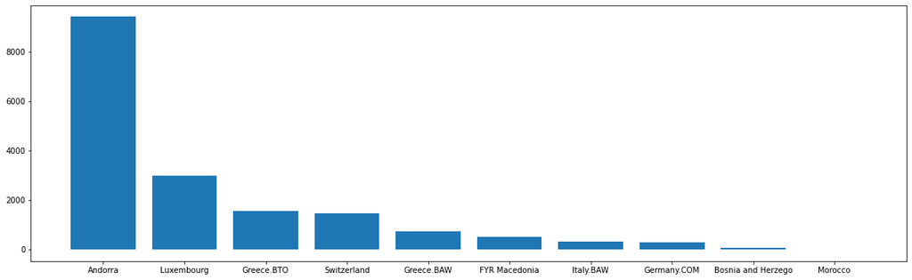

```python
plt.figure(figsize=(20,6))
plt.bar(PAB_data_10_duration_median_loss_median.CountryName,PAB_data_10_duration_median_loss_median.total_net_loss)
```

```python
PAB_data_10_duration_median_spent_median = PAB_data_10_duration_median_spent.groupby(["CountryName"]).median().sort_values(by="total_spent", ascending=False).reset_index()
PAB_data_10_duration_median_spent_median
```

|  | CountryName | spent_fixedodds | spent_liveaction | spent_casino | total_spent |
| --- | --- | --- | --- | --- | --- |
| 0 | Andorra | 24290.692800 | 118951.137200 | NaN | 143241.830000 |
| 1 | Luxembourg | 7554.695200 | 12877.222300 | 24974.68000 | 33961.500000 |
| 2 | Greece.BTO | 1988.010000 | 1476.830000 | 19771.42500 | 25623.140000 |
| 3 | Switzerland | 1308.104912 | 875.599743 | 11593.83675 | 22385.805300 |
| 4 | Greece.BAW | 1843.160000 | 969.300000 | 7729.15000 | 10551.359700 |
| 5 | Germany.COM | 644.080000 | 1632.542100 | 1268.91500 | 2709.915000 |
| 6 | Italy.BAW | 368.793600 | 236.930000 | 59207.51470 | 2631.830000 |
| 7 | FYR Macedonia | 40.030000 | 1845.259900 | NaN | 1885.289900 |
| 8 | Bosnia and Herzego | 988.992300 | 71.000000 | 1759.74500 | 1546.642300 |
| 9 | Morocco | 61.595935 | 44.306387 | NaN | 105.902322 |

```
<BarContainer object of 10 artists>
```

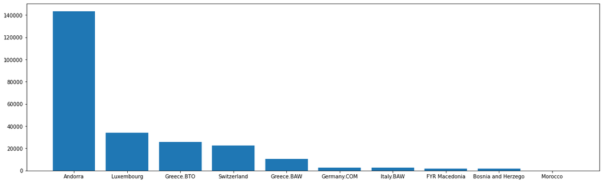

```python
plt.figure(figsize=(20,6))
plt.bar(PAB_data_10_duration_median_spent_median.CountryName,PAB_data_10_duration_median_spent_median.total_spent)
```

```python
PAB_data_10_duration_median_join = pd.concat([PAB_data_10_duration_median_loss_median[["CountryName","total_net_loss"]].sort_values(by="CountryName").reset_index(drop=True),PAB_data_10_duration_median_spent_median.sort_values(by="CountryName").reset_index(drop=True)[["total_spent"]]], axis="columns")
PAB_data_10_duration_median_join
```

|  | CountryName | total_net_loss | total_spent |
| --- | --- | --- | --- |
| 0 | Andorra | 9408.89000 | 143241.830000 |
| 1 | Bosnia and Herzego | 40.00000 | 1546.642300 |
| 2 | FYR Macedonia | 498.96990 | 1885.289900 |
| 3 | Germany.COM | 260.26260 | 2709.915000 |
| 4 | Greece.BAW | 714.44000 | 10551.359700 |
| 5 | Greece.BTO | 1550.66000 | 25623.140000 |
| 6 | Italy.BAW | 318.16720 | 2631.830000 |
| 7 | Luxembourg | 2974.50000 | 33961.500000 |
| 8 | Morocco | -12.77465 | 105.902322 |
| 9 | Switzerland | 1441.25830 | 22385.805300 |

```python
PAB_data_10_duration_median_join["total_earn"] = PAB_data_10_duration_median_join.total_net_loss + PAB_data_10_duration_median_join.total_spent
PAB_data_10_duration_median_join
```

|  | CountryName | total_net_loss | total_spent | total_earn |
| --- | --- | --- | --- | --- |
| 0 | Andorra | 9408.89000 | 143241.830000 | 152650.720000 |
| 1 | Bosnia and Herzego | 40.00000 | 1546.642300 | 1586.642300 |
| 2 | FYR Macedonia | 498.96990 | 1885.289900 | 2384.259800 |
| 3 | Germany.COM | 260.26260 | 2709.915000 | 2970.177600 |
| 4 | Greece.BAW | 714.44000 | 10551.359700 | 11265.799700 |
| 5 | Greece.BTO | 1550.66000 | 25623.140000 | 27173.800000 |
| 6 | Italy.BAW | 318.16720 | 2631.830000 | 2949.997200 |
| 7 | Luxembourg | 2974.50000 | 33961.500000 | 36936.000000 |
| 8 | Morocco | -12.77465 | 105.902322 | 93.127671 |
| 9 | Switzerland | 1441.25830 | 22385.805300 | 23827.063600 |

```
<BarContainer object of 10 artists>
```

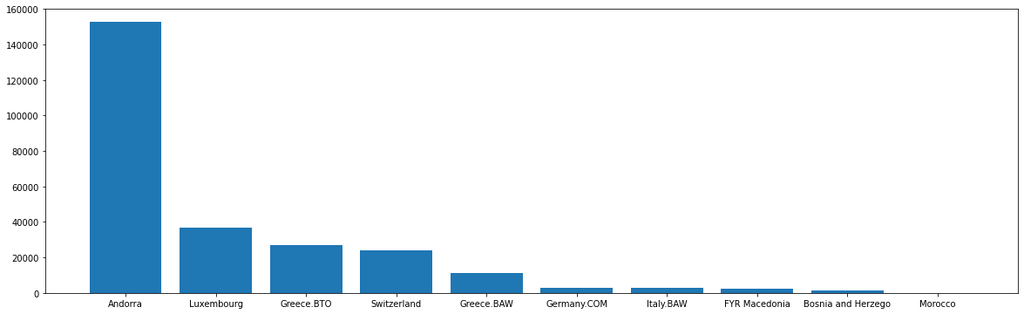

```python
plt.figure(figsize=(20,6))
plt.bar(PAB_data_10_duration_median_join.sort_values(by="total_earn",ascending=False).CountryName,PAB_data_10_duration_median_join.sort_values(by="total_earn",ascending=False).total_earn)
```

```python
PAB_data_10_duration_median_join["spent_loss_ratio"] = PAB_data_10_duration_median_join["total_spent"]/PAB_data_10_duration_median_join["total_net_loss"]
PAB_data_10_duration_median_join
```

|  | CountryName | total_net_loss | total_spent | total_earn | spent_loss_ratio |
| --- | --- | --- | --- | --- | --- |
| 0 | Andorra | 9408.89000 | 143241.830000 | 152650.720000 | 15.224094 |
| 1 | Bosnia and Herzego | 40.00000 | 1546.642300 | 1586.642300 | 38.666058 |
| 2 | FYR Macedonia | 498.96990 | 1885.289900 | 2384.259800 | 3.778364 |
| 3 | Germany.COM | 260.26260 | 2709.915000 | 2970.177600 | 10.412234 |
| 4 | Greece.BAW | 714.44000 | 10551.359700 | 11265.799700 | 14.768714 |
| 5 | Greece.BTO | 1550.66000 | 25623.140000 | 27173.800000 | 16.524022 |
| 6 | Italy.BAW | 318.16720 | 2631.830000 | 2949.997200 | 8.271846 |
| 7 | Luxembourg | 2974.50000 | 33961.500000 | 36936.000000 | 11.417549 |
| 8 | Morocco | -12.77465 | 105.902322 | 93.127671 | -8.290037 |
| 9 | Switzerland | 1441.25830 | 22385.805300 | 23827.063600 | 15.532126 |

# Results Findings & Conclusion

For each research question, summarize in 2-3 visualizations which will answer the question. Intrepret the results accordingly and give your observation and conclusion. The visualizations should be well presented (apply what you have learnt in Chapter 9 on data communication). The plots shown here could be an enhanced version of the EDA plots, or presented in another format.

Question 1:

|  | Information | Form | Value |
| --- | --- | --- | --- |
| 0 | spent | fixed_odds | 21.873200 |
| 1 | spent | live_action | 58.430355 |
| 2 | spent | casino | 198.194211 |
| 3 | net_loss | fixed_odds | 154.282250 |
| 4 | net_loss | live_action | 197.415000 |
| 5 | net_loss | casino | 89.200000 |
| 6 | total_earned | fixed_odds | 183.246763 |
| 7 | total_earned | live_action | 289.773866 |
| 8 | total_earned | casino | 356.195882 |

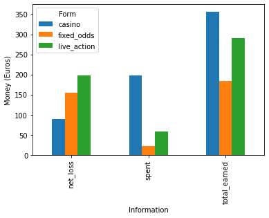

```python
plt.figure(figsize=(8,6))

num_df = pd.concat([PAB_data_case_spent.median(),PAB_data_case_loss.median(),PAB_data_case_total_earned.median()]).reset_index(drop=True)
info_df = pd.Series(["spent","spent","spent","net_loss","net_loss","net_loss","total_earned","total_earned","total_earned"])
form_df = pd.Series(["fixed_odds","live_action","casino","fixed_odds","live_action","casino","fixed_odds","live_action","casino"])

final_df = pd.DataFrame({"Information":info_df,"Form":form_df,"Value":num_df})

pd.pivot_table(final_df, index= 'Information', columns= 'Form', values= "Value").plot(kind= 'bar')
plt.ylabel("Money (Euros)")

final_df
```

|  | Information | Form | Value |
| --- | --- | --- | --- |
| percent_lost_fixedodds | percent_lost | fixed_odds | 0.214543 |
| percent_lost_liveaction | percent_lost | live_action | 0.092172 |
| percent_lost_casino | percent_lost | casino | 0.065257 |

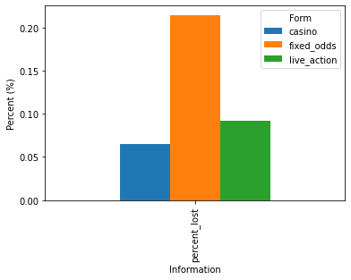

```python
final_df_2 = pd.DataFrame({"Information":["percent_lost","percent_lost","percent_lost"],"Form":["fixed_odds","live_action","casino"],"Value":PAB_data_case_lost.median()})

pd.pivot_table(final_df_2, index= 'Information', columns= 'Form', values= "Value").plot(kind= 'bar')
plt.ylabel("Percent (%)")
final_df_2
```

|  | Information | Form | Value |
| --- | --- | --- | --- |
| duration_fixedodds | duration | fixed_odds | 766.5 |
| duration_liveaction | duration | live_action | 726.0 |
| duration_casino | duration | casino | 250.0 |

[figure not shown]

```python
final_df_3 = pd.DataFrame({"Information":["duration","duration","duration"],"Form":["fixed_odds","live_action","casino"],"Value":PAB_data_case_duration_median})

pd.pivot_table(final_df_3, index= 'Information', columns= 'Form', values= "Value").plot(kind= 'bar')
plt.ylabel("Percent (%)")
final_df_3
```

Conclusion: Having a low net loss and a low percent lost rate as well as a high income, it's no suprise that gambling at casino's are the favoured of the three from the perspective of the gamblers and the owners. However, the low duration spent in casino is surprising, but in conjunction with the high daily spending rate, we can somewhat conclude a fact: Very few people go to the casino on a regular basis, but when they do, they spend a lot of money.Question 2:

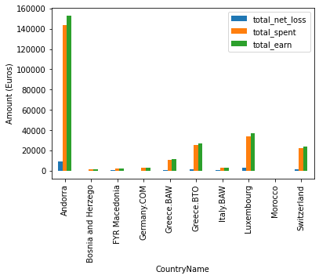

```python
plt.figure(figsize=(10,8))

PAB_data_10_duration_median_join.set_index(PAB_data_10_duration_median_join.CountryName).drop(["CountryName"],axis="columns")[["total_net_loss","total_spent","total_earn"]].plot.bar()

plt.ylabel("Amount (Euros)")

plt.show()
```

# Recommendations or Further Works

State any recommendations, improvements or further works.

My recommendation for further works is to get data from the Gambling companies like casinos or betting houese. These data would be more accurate and if collected in masses, can lead us to a better answer.

As for improvements, being able to utilise well the many datasets that I wanted to will skyrocket the quality of this project. Better quality questions would also have been bettet.

# References

Cite any references made, and links where you obtained the data. You may wish to read about how to use markdown in Jupyter notebook to make your report easier to read. https://www.ibm.com/docs/en/db2-event-store/2.0.0?topic=notebooks-markdown-jupyter-cheatsheet

**[The Transparency Project](http://www.thetransparencyproject.org/download_index.php)**